# Student Sit In

Cortajha Hunter

10/26/2019

# ONE SHOT assignment!

this is an extra credit assignment, must be completed Monday Oct 28, turn-in closes at midnight!

## Problem statement:

Students at UCD- is there a relation between where one sits and one’s major?

## Introduction

$H_0$: there is no relationship between one’s major and where one sits in a class  
$H_A$: where one sits in class and one’s major are related

## Methods

In this data chart; the percentage of student were either enrolled into Liberal Arts or Non-Liberal Art and it shows the percentages of the students who sat in the back, front, and middle of the classroom.

## Data summary

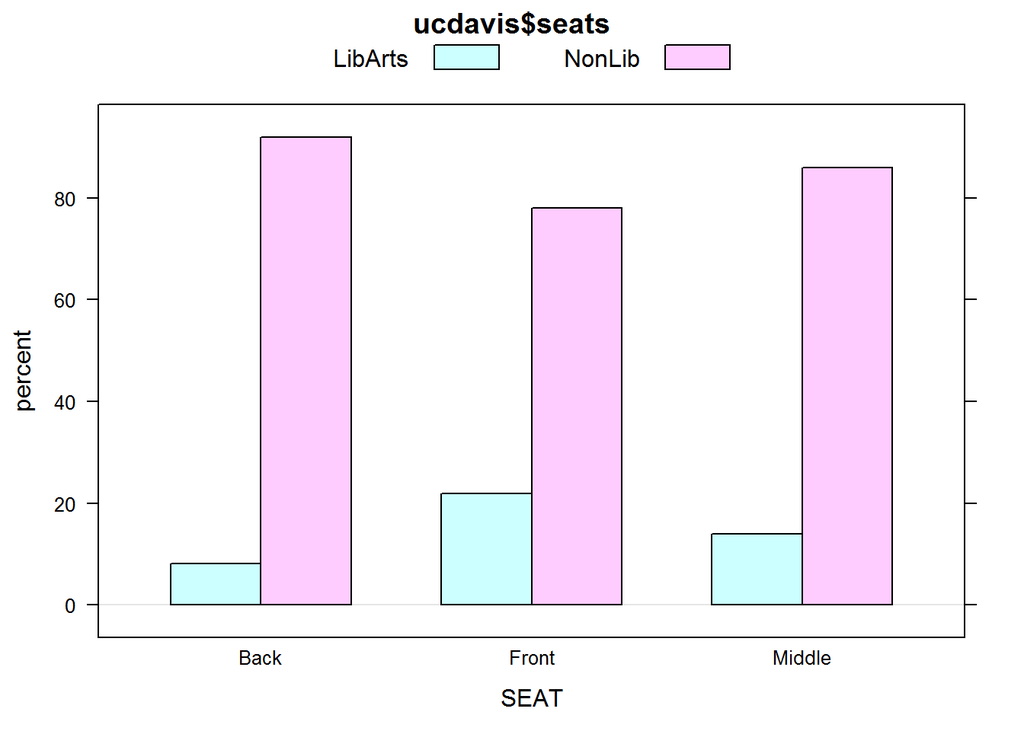

```r
tab=xtabs(~Seat+class, data=ucdavis1)
print(tab)
```

```
##         class
## Seat     LibArts NonLib
##   Back         3     34
##   Front        9     32
##   Middle      13     80
```

Explain what the numeric summary says that the student whom are in Liberal Arts shows similar, yet low numbers, while there is an increase in the Non-Liberal students.

## Inferential Results

```r
chisqtestGC(tab)
```

```
## Pearson's Chi-squared test
##
## Observed Counts:
##         class
## Seat     LibArts NonLib
##   Back         3     34
##   Front        9     32
##   Middle      13     80
##
## Counts Expected by Null:
##         class
## Seat     LibArts NonLib
##   Back      5.41  31.59
##   Front     5.99  35.01
##   Middle   13.60  79.40
##
## Contributions to the chi-square statistic:
##         class
## Seat     LibArts NonLib
##   Back      1.07   0.18
##   Front     1.51   0.26
##   Middle    0.03   0.00
##
##
## Chi-Square Statistic = 3.053
## Degrees of Freedom of the table = 2
## P-Value = 0.2173
```

what is the p-value? .22 > .05